# Rescorla Wagner Model and Congruent Limb Movements

## 4.4 Integrated Graph

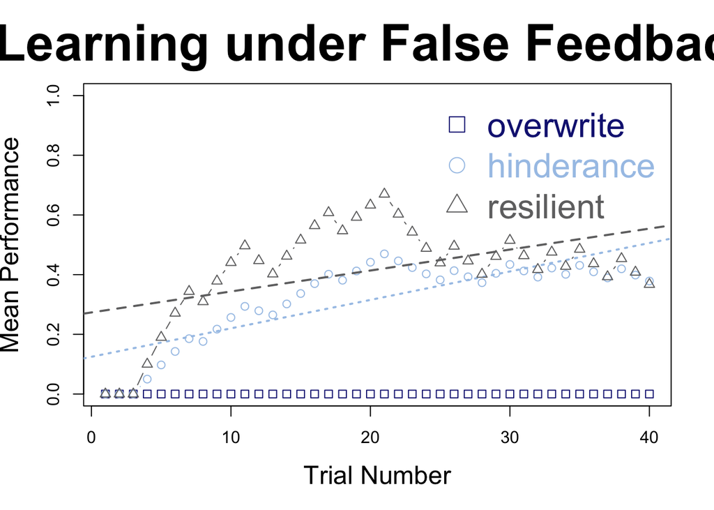

```r
# plot characters: http://www.sthda.com/english/wiki/r-plot-pch-symbols-the-different-point-shapes-available-in-r
dark_blue = "#161F81FF" # rgb(22, 31, 129, 0.5, maxColorValue = 255)
light_blue = "#A7C5E8FF"  # rgb(167, 197, 232, 0.95, maxColorValue = 255)
my_grey = "#707071FF" # rgb(112, 112, 113, 0.95, maxColorValue = 255)

#par(oma = c(2, 2, 2, 2)) # Set the margin on all sides to 2

plot(
  strength_overwrite,
  main = "Learning under False Feedback",
  xlab = "Trial Number",
  ylab = "Mean Performance",
  #pch = 1,
  pch = 0,
  type="b",
  col=dark_blue,
  ylim=c(0,1.0),
  cex.main = 3.0,
  cex.lab = 1.5
)

#strength_data_and_trial <- data.frame(strength=strength_overwrite, trial=1:40)
#model <- lm(strength  ~ trial, strength_data_and_trial)
#abline(model, lwd = 2, col=dark_blue, type="solid")

#title(main = "Learning under False Feedback")

lines(
  x = 1:40,
  y = strength_hinderance[1:40],
  col=light_blue,
  #lty="dotted",
  #lwd="2",
  type="b",
  pch=1
)

strength_data_and_trial <- data.frame(strength=strength_hinderance, trial=1:40)
model <- lm(strength  ~ trial, strength_data_and_trial)
abline(model, lwd = 2, col=light_blue, lty="dotted")

lines(
  x = 1:40,
  y = strength_resilient[1:40],
  #pch=0,
  type="b",
  pch = 2,
  col=my_grey
)

strength_data_and_trial <- data.frame(strength=strength_resilient, trial=1:40)
model <- lm(strength  ~ trial, strength_data_and_trial)
abline(model, lwd = 2, col=my_grey, lty="dashed")

legend("topright", text.col=c(dark_blue, light_blue, my_grey), col = c(dark_blue, light_blue, my_grey), legend = c("overwrite", "hinderance", "resilient"), pch = c(0, 1, 2), bty = "n", cex=2.0)
```

*Performance: Likelihood to move correct finger*

# 5 Extended Model II - All fingers learn dependent from each other

A future experiment design should formulate a model that is closer to reality when concerning learning rates for finger movements. Considering all fingers of two hands as one motor primitive is too simple. In reality, the likelihood to move the correct finger in the paradigm is dependent on the side of the hand. In other words it is more likely to confuse the contra- vs ipsilateral finger.

## 5.1 Extended (hierarchical) Model III - Left vs right hand as additional parameter

Same as the extended model. Additionally the distance between each finger is considered. In other words it is more likely to confuse the neighboring finger–i.e. index and middle vs index and pinky finger.